# NHL Salary Prediction Analysis

The NHL and many other interested parties collect and derive an almost uncountable number of statistics related to player performance

the following data domains have many variables each

- All-in-one stats aggregate stats like Point Shares
- Contractual information
- The equipment the player uses
- Stats about faceoffs
- Additional information about the player’s goals and shots.
- How the team performs with that player on the ice
- Stats about penalties taken and drawn
- demographics
- Stats about a player’s deployment
- Traditional stats, like goals and assists
- How the player’s opponents perform, quality of competition
- How the player’s teammates perform
- The team’s shot attempt stats when the player was on the ice
- The team’s unblocked shot attempts when the player was on the ice
- How the team goal stats when player on the ice
- How the team does in terms of scoring chances/ect
- How the team does on the shot clock with that player on the ice
- The zones in which a player’s shifts started

Many of these variables are duplicates across palyer situations including total stats (TOT), even strength (ES) stats, power play (PP), and penitly kill (PK) stats. The punchline is that we have several hundred variables at our disposal.

## Data Setup

Setup your working directory:

```r
setwd("C:/Users/farre/Desktop/nhl")
```

Import the data:

The data has been collected and merged into .CSV files from the following sources

https://www.hockeyabstract.com

https://www.hockey-reference.com/

http://corsica.hockey/

https://www.corsicahockey.com/nhl/players/nhl-player-stats

```r
data <- import("./data")
```

```
##
## Importing 2018...
##
## [1] "Importing: ./data/2018_ES.csv"
## [1] "Importing: ./data/2018_PK.csv"
## [1] "Importing: ./data/2018_PP.csv"
## [1] "Importing: ./data/2018_TOT.csv"
```

I’m not going very deep into what variables are polluted due to the amount of time this has taken and doing so would take, but there are some variables that are clearly polluted and their values should be checked. For example, `TOT_CHIP` has values that have monetary representations but also others that don’t, and which don’t seem to be in the same units of scale. When doing the data cleaning, this are all transformed into numeric variables, but they are problematic and should be investigated further. THis variable will be removed from the anlysis.

The proportion of NAs in the data is very large. So we need a mechanism to reduce the proportion of NAs while trying to keep most of the useful information.

If you want to see proportions in a case-by-case (i.e. “by row” or “by column”), you can remove the `summary()` function that is wrapping it.

```r
summary(proportion_of_nas_per_observation(data))
```

```
##     Min.  1st Qu.   Median     Mean  3rd Qu.     Max.
## 0.000000 0.007519 0.013534 0.074063 0.031203 0.765413
```

```r
summary(proportion_of_nas_per_variable(data))
```

```
##    Min. 1st Qu.  Median    Mean 3rd Qu.    Max.
## 0.00000 0.04301 0.04301 0.07406 0.04301 0.84194
```

To reduce the NA proportions in the data, we look for observations and variables that have proportions larger than `NA_OBS_PROPORTION_THRESHOLD` and `NA_VAR_PROPORTION_THRESHOLD`, respectively, and delete them if they do. In the case of variables, there’s a `NA_VAR_WHITELIST` variable that will keep any variables inside it, even if they don’t pass the NAs proportion test. All of these constants can be modified in the `constants.R` file.

```r
before_n_obs <- nrow(data)
before_n_vars <- ncol(data)
```

```r
data <- clean(data)
```

```
##
## Cleaning non-whitlisted character variables...
##
##
## Keeping variables with acceptable NA proportions...
##
##
## Keeping observations with acceptable NA proportions...
##
##
## Keeping observations non-NA salary...
##
##
## Disaggregating due to players with multiple teams...
##
##  [1] "NSH, EDM"           "PHI, COL"           "PIT, ARI"
##  [4] "BOS, NYR"           "OTT, PIT"           "TBL, ANA"
##  [7] "LAK, EDM"           "SJS, VGK"           "NYI, ANA"
## [10] "WSH, CBJ"           "PIT, CBJ"           "DAL, NYR"
## [13] "MTL, EDM, NYI"      "LAK, VAN"           "COL, OTT"
## [16] "ARI, CHI"           "TBL, OTT"           "TOR, SJS"
## [19] "LAK, OTT"           "NSH, COL"           "NYR, NJD"
## [22] "CGY, ARI"           "NJD, ANA"           "NYR, BOS"
## [25] "MTL, WSH"           "EDM, LAK, CBJ, VAN" "CAR, PIT"
## [28] "BUF, SJS"           "CHI, WSH"           "VGK, VAN"
## [31] "EDM, CBJ"           "EDM, NJD"           "NYR, TBL"
## [34] "NSH, NYR"           "MTL, LAK"           "MTL, WPG"
## [37] "TBL, NYR"           "SJS, BUF"           "OTT, PHI"
## [40] "DAL, PIT"           "STL, OTT"           "CHI, ARI"
## [43] "OTT, LAK"           "MTL, TOR"           "STL, MIN"
## [46] "PIT, VGK"           "MIN, MTL"           "ANA, MTL"
## [49] "DET, PIT"           "LAK, OTT, CGY"      "TOR, STL"
## [52] "STL, WPG"           "MIN, CGY"           "DET, VGK"
## [55] "OTT, NSH"           "VAN, CBJ"           "ANA, NJD"
## [58] "BOS, FLA"           "WSH, EDM"           "PIT, DET, BUF"
```

We apply our cleaning process and this also acts as an initial variable selection procedure, and it can be relaxed or made more restrictive by modifying the `NA_OBS_PROPORTION_THRESHOLD` and `NA_VAR_PROPORTION_THRESHOLD` in the `constants.R` file.

```r
summary(proportion_of_nas_per_observation(data))
```

```
##     Min.  1st Qu.   Median     Mean  3rd Qu.     Max.
## 0.000000 0.000000 0.004637 0.022953 0.010819 0.417311
```

```r
summary(proportion_of_nas_per_variable(data))
```

```
##     Min.  1st Qu.   Median     Mean  3rd Qu.     Max.
## 0.000000 0.000000 0.001097 0.022953 0.001097 0.381579
```

```r
ncol(data) / before_n_vars
```

```
## [1] 0.9729323
```

```r
nrow(data) / before_n_obs
```

```
## [1] 0.9806452
```

This is the clean and pre-processed data set, and it’s saved for reference (before teh variable selection process is applied), since it may be easier to check for correctness outside of R.

```r
write.csv(data, "./data.csv", row.names = FALSE)
dim(data)
```

```
## [1] 912 647
```

The cleaning process has left us with 912 cases (players) 647 variables including one dependent.

Now we are going to impute the mode to each NA in each categorical variable, and the mean for numerical variables. There is still very large number of NAs. These will produce errors in our variable selection and model training processes. After the imputation, we separete the data into our train, test, and full data sets

```r
data <- separate(impute(data))
```

## Visualizations

Here is a look a the shape of the Salary distribution:

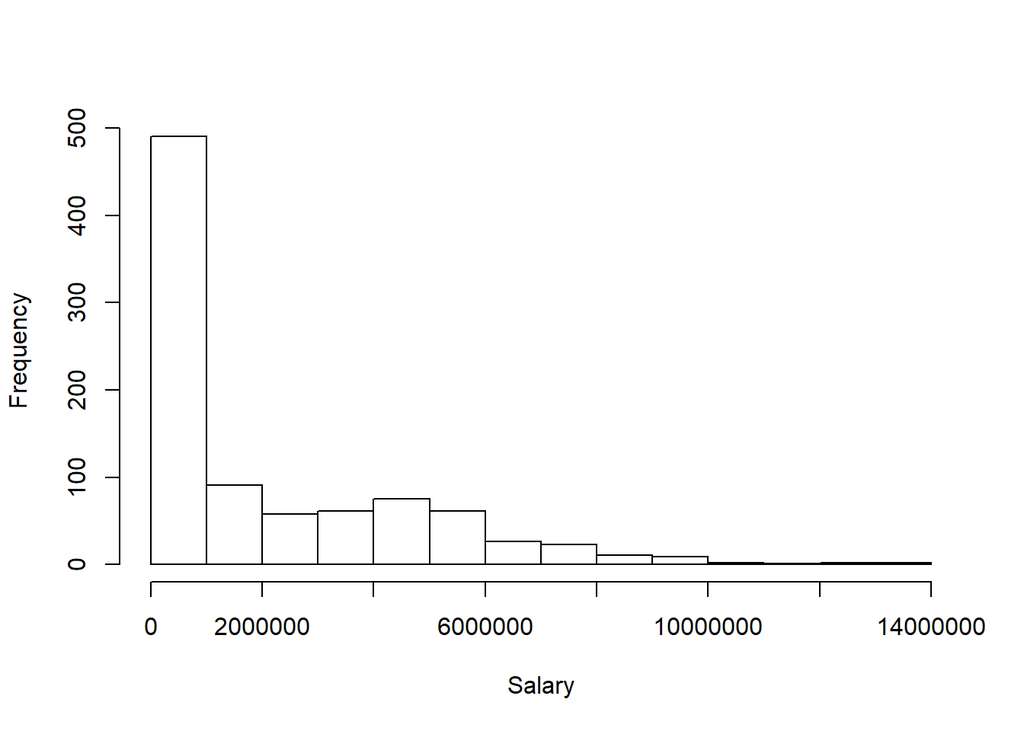

```r
options(scipen = 999)
hist(data[["full"]]$Salary, main = NULL, xlab = "Salary")
```

correlation and scatter plots for variable exploration:

Since there’s a very large number of numeric variables, we can’t generate a single correlations plots that has all the information simultaneously. We show the correlations by variable random samples, which means that you should execute the following code multiple times to get a rough estimate of the correlations among all variables.

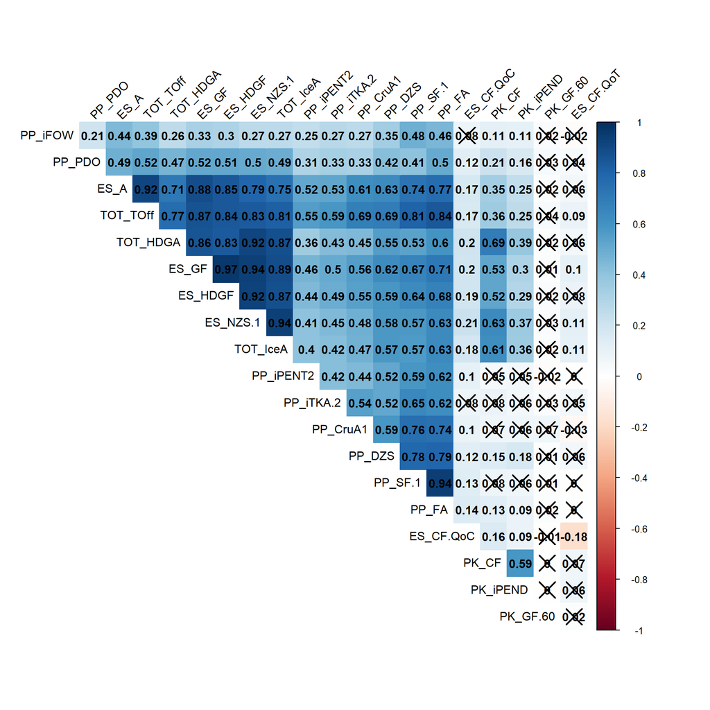

```r
random_correlations_graph(data, n_variables = 20)
```

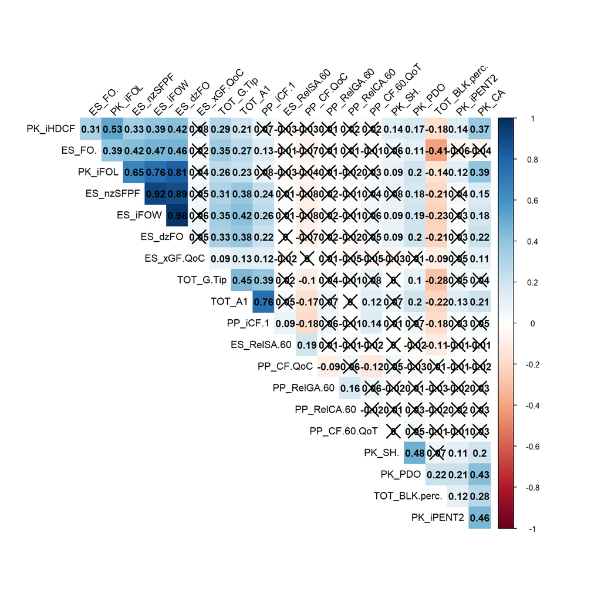

```r
random_correlations_graph(data, n_variables = 20)
```

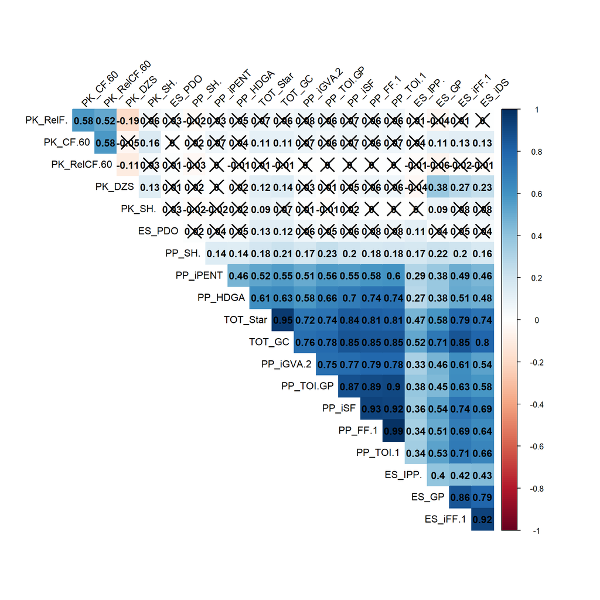

```r
random_correlations_graph(data, n_variables = 20)
```

The following code automatically generate multiple correlations graphs and saves them to disk for you. You can modify the parameters to your liking. Values marked with a cross on top of them mean that their p-value is larger than 0.01.

```r
generate_multiple_random_correlation_graphs(
    n_variables = 20,
    n_graphs = 10,
    data = data
)
```

We are also able to create scatter plots where the size of each point is determined a variable’s value, and the color is determined by the salary. Some examples of the different patterns that can be found with these graphs are the following. Note that to interpret these correctly, good domain knowledge about NHL and the measured variables is required. But even if you know nothing, some interesting ideas can be infered for data cleaning and feature engineering purposes. Like the folowing, there are many other interesting patterns hidden in this data.

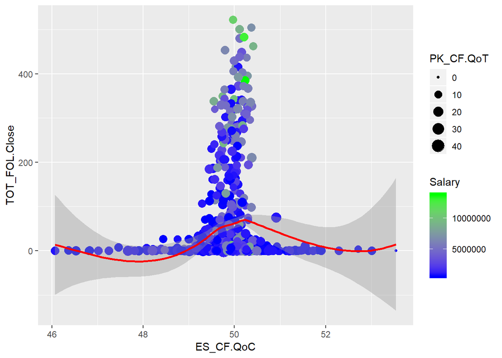

```r
scatter_graph_with_size_and_salary_color(
    data,
    x = "ES_CF.QoC",
    y = "TOT_FOL.Close",
    size = "PK_CF.QoT"
)
```

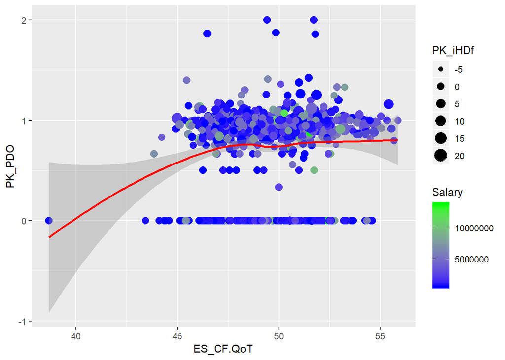

```r
scatter_graph_with_size_and_salary_color(
    data,
    x = "ES_CF.QoT",
    y = "PK_PDO",
    size = "PK_iHDf"
)
```

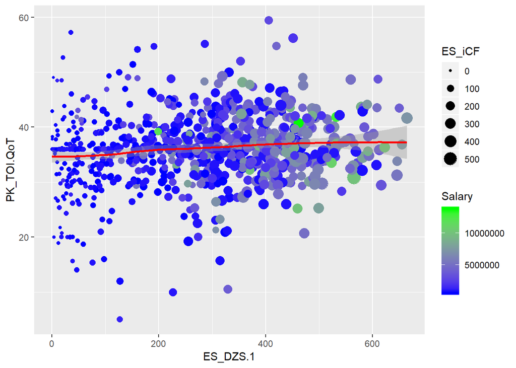

```r
scatter_graph_with_size_and_salary_color(
    data,
    x = "ES_DZS.1",
    y = "PK_TOI.QoT",
    size = "ES_iCF"
)
```

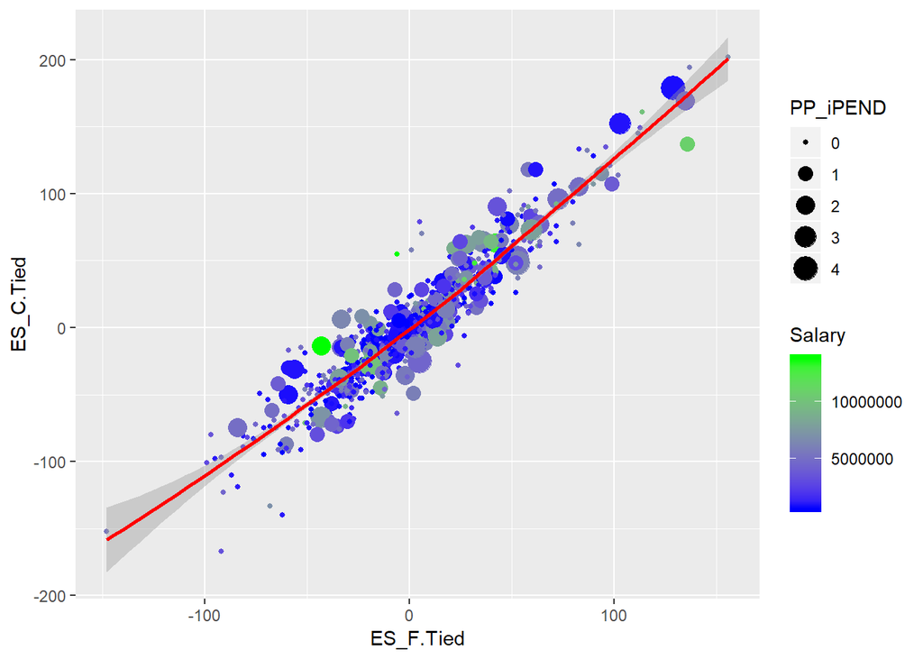

```r
scatter_graph_with_size_and_salary_color(
    data,
    x = "ES_F.Tied",
    y = "ES_C.Tied",
    size = "PP_iPEND"
)
```

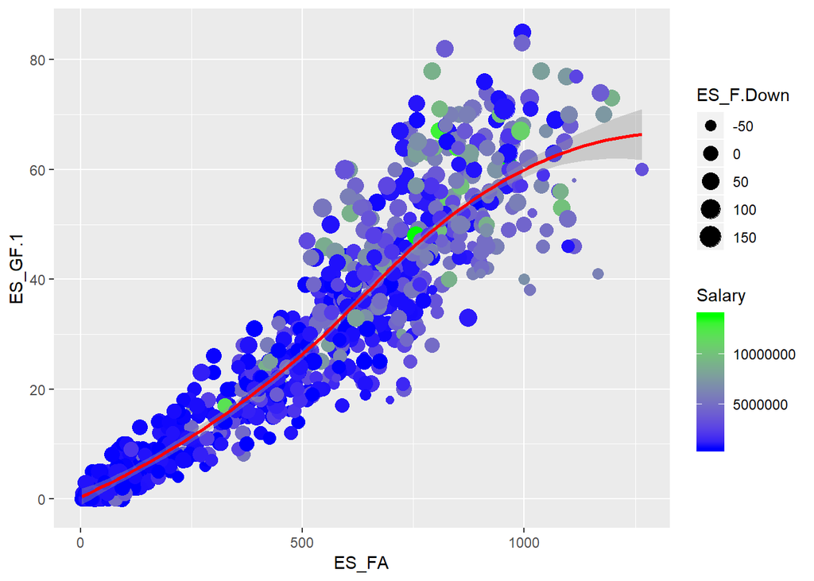

```r
scatter_graph_with_size_and_salary_color(
    data,
    x = "ES_FA",
    y = "ES_GF.1",
    size = "ES_F.Down"
)
```

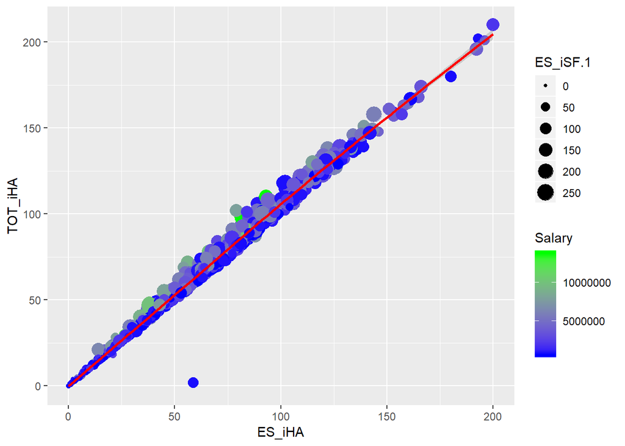

```r
scatter_graph_with_size_and_salary_color(
    data,
    x = "ES_iHA",
    y = "TOT_iHA",
    size = "ES_iSF.1"
)
```

To create `n_graphs` random graphs (the combinations for all available graphs are too much to create at once, it would be around 10,827,401) we use the following:

> **CAUTION**: The following code can take a long time to finish depending on how many graphs you specify. To avoid any problems, it’s not activiated here and is just left as reference.

```r
generate_multiple_random_scatter_graphs(
    n_graphs = 100,
    data = data
)
```

The scatter plots created show some very interesting behavior for many combinations. Those visualizations together with domain knowledge around the problem can help with cleaning and feature engineering to increase the predictive power of the models, and it’s something that I to be explored further.

## Variable Selection

Variable selection is performed with two steps. First, we remove variables to address Multicollinearity. The logic behind this is that if predictors are highly correlated with each other the information they provide for the analysis is redundant, and, given the large number of variables in the analysis, we want to minimize the number of them while we maximize the information kept. The second step is performed with Recursive Feature Elimination (RFE).

The `selection` object contains the following attributes: `data` which is the data with the variable selection applied, `graph` which shows the accuracy change as more variables are added, `n_variables` which is the number of variables selected, and `variables` which are the variables actually selected. Internally, Random Forests are used to measure variable importance.

```r
selection <- variable_selection(data, "Salary")
```

```
##
## Removing variables with high correlations...
##
##
## Variables removed (479):
##
##
##   [1] "ES_CA.1"       "ES_CA.2"       "ES_CA.3"       "ES_CF"
##   [5] "ES_CF."        "ES_CF.1"       "ES_CF.2"       "ES_CF.3"
##   [9] "ES_CF.60"      "ES_CF.QoC"     "ES_CF.QoT"     "ES_CruA1"
##  [13] "ES_CruA2"      "ES_CruG"       "ES_DZS.1"      "ES_DZS.2"
##  [17] "ES_dzSAPF"     "ES_dzSFPF"     "ES_Exp.dzNGPF" "ES_Exp.dzNSPF"
##  [21] "ES_Exp.ozNGPF" "ES_Exp.ozNSPF" "ES_F.Close"    "ES_FA"
##  [25] "ES_FA.1"       "ES_FA.2"       "ES_FA.3"       "ES_FF"
##  [29] "ES_FF.1"       "ES_FF.2"       "ES_FF.3"       "ES_FOvsL"
```

[output cut: 220 more lines]

To explore the selection results, you can use the following to see the filtered datasets, variables, and optimization graph.

```r
head(selection[["data"]][["full"]])
head(selection[["data"]][["train"]])
head(selection[["data"]][["test"]])
```

```r
selection[["n_variables"]]
```

```
## [1] 65
```

```r
selection[["variables"]]
```

```
##  [1] "TOT_Debut"     "TOT_Status"    "PP_TOI.QoT"    "PP_DZS"
##  [5] "TOT_DftYr"     "ES_xGA.60.QoC" "PK_iGVA.1"     "PP_CruG"
##  [9] "PP_TOI.QoC"    "ES_TOI.QoT"    "TOT_Over"      "PP_iTKA.1"
## [13] "TOT_PAX"       "PP_iHF.1"      "ES_RopFOW"     "PP_CA.60.QoC"
## [17] "PK_iTKA.1"     "PP_ZS."        "TOT_WAR"       "PP_iHDf"
## [21] "ES_F.Tied"     "PP_HDGA"       "PK_iHDf"       "ES_F.Up"
## [25] "ES_CriA1"      "PK_iHA"        "PP_TOff.60"    "TOT_DftRd"
## [29] "ES_iPEND.1"    "PP_RelZS."     "PP_IPP."       "TOT_Post"
## [33] "PP_CriG"       "PP_CF.60.QoT"  "PP_iBLK"       "PP_SV."
## [37] "PP_RelxGF.60"  "TOT_G.Slap"    "ES_xGF.QoC"    "PK_iRush"
## [41] "PP_PTS.60"     "ES_iRush"      "PP_RelGF.60"   "TOT_G.Snap"
## [45] "ES_iHDf"       "TOT_EPM"       "PP_CriA2"      "TOT_Cntry"
## [49] "ES_F.Down"     "TOT_NPD"       "ES_CA.60.QoC"  "PK_RelSH."
## [53] "PP_RelxGA.60"  "ES_RelSF."     "TOT_DWAR"      "PP_FO."
## [57] "PK_RelSV."     "PP_iRush"      "ES_CriA2"      "TOT_PM"
## [61] "Position"      "PK_xGF.60.QoC" "ES_iHF.2"      "TOT_OTG"
## [65] "ES_RelxGA.60"
```

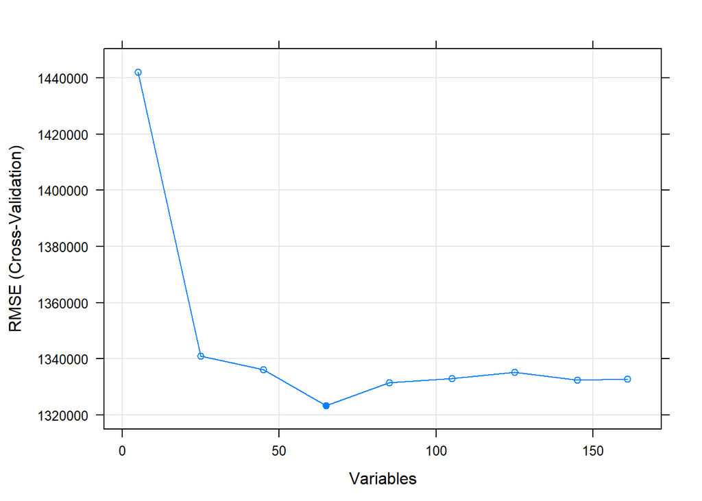

```r
selection[["graph"]]
```

## Model Application

Using the model vector and called funtions simplifies the process of training, tuning and applying the models to the data. I am comparing the GLM, KNN and RF models. The full list is here: list here: https://topepo.github.io/caret/available-models.html

These models depend on external packages. If you don’t have installed in your system, when you execute the code, you’ll be notified that you don’t have them, and you’ll be asked whether you want to install them. If you do, execution will continue normally after the corresponding installations.

```r
models <- list(
    "random_forest" = "rf",
    "linear_regression" = "glm",
    "k_nearest_neighbors" = "knn"
)
```

```r
results <- best_results(selection[["data"]], "Salary", models)
```

```
## [1] "    - random_forest"
## [1] "    - linear_regression"
```

```
## [1] "    - k_nearest_neighbors"
```

## Results Exploration

The `metrics` attribute has find three different accuracy metrics: `RMSE` (Root Mean Squared Error), `MAPE` (Mean Absolute Percentage Error), and `PPE10` (Percentage Predicted Error within 10%).

Models available:

```r
names(results)
```

```
## [1] "random_forest"       "linear_regression"   "k_nearest_neighbors"
```

Random Forest results:

```r
names(results[["random_forest"]])
```

```
## [1] "metrics"    "predictor"  "importance"
```

See the `predictor` object for Random Forests:

```r
results[["random_forest"]][["predictor"]]
```

```
## Random Forest
##
## 638 samples
##  65 predictor
##
## No pre-processing
## Resampling: Cross-Validated (3 fold)
## Summary of sample sizes: 425, 425, 426
## Resampling results across tuning parameters:
##
##   mtry  RMSE     Rsquared   MAE
##    2    1641902  0.6238323  1161997.6
##   44    1393557  0.6882421   877311.3
##   86    1428273  0.6678164   880276.0
##
## RMSE was used to select the optimal model using the smallest value.
## The final value used for the model was mtry = 44.
```

The results I’m seeing in average are the following. Note that these may be different every time you run the analysis because we’re not controlling the “seed” for the randomized algorithmns (this is done on purpose to see variuos results, but for publishing or sharing results with someone else, we should control the seed).

| Model | Metric | Value |
| --- | --- | --- |
| k-Nearest Neighbors | MAPE | 0.73 |
| k-Nearest Neighbors | RMSE | 1,124,504 |
| k-Nearest Neighbors | PPE10 | 0.1843 |
| Linear Regression | MAPE | 0.82 |
| Linear Regression | RMSE | 1,029,118 |
| Linear Regression | PPE10 | 0.1099 |
| Random Forest | MAPE | 0.4722 |
| Random Forest | RMSE | 720,575 |
| Random Forest | PPE10 | 0.2553 |

The results without the `Team` variable are (may be different for you):

| Model | Metric | Value |
| --- | --- | --- |
| k-Nearest Neighbors | MAPE | 0.7182 |
| k-Nearest Neighbors | RMSE | 1,145,584 |
| k-Nearest Neighbors | PPE10 | 0.1276 |
| Linear Regression | MAPE | 0.7932 |
| Linear Regression | RMSE | 1,022,017 |
| Linear Regression | PPE10 | 0.1134 |
| Random Forest | MAPE | 0.4237 |
| Random Forest | RMSE | 759,186 |
| Random Forest | PPE10 | 0.2234 |

Also note that these results show that the predictive powerful for these models is not good.

```r
results[["k_nearest_neighbors"]][["metrics"]]
```

```
## $RMSE
## [1] 1364904
##
## $MAPE
## [1] 0.8986147
##
## $PPE10
## [1] 0.120438
```

```r
results[["linear_regression"]][["metrics"]]
```

```
## $RMSE
## [1] 1148664
##
## $MAPE
## [1] 0.9176982
##
## $PPE10
## [1] 0.1240876
```

```r
results[["random_forest"]][["metrics"]]
```

```
## $RMSE
## [1] 762385
##
## $MAPE
## [1] 0.5076859
##
## $PPE10
## [1] 0.2080292
```

See the “variable” `importance`, for a Random Forests

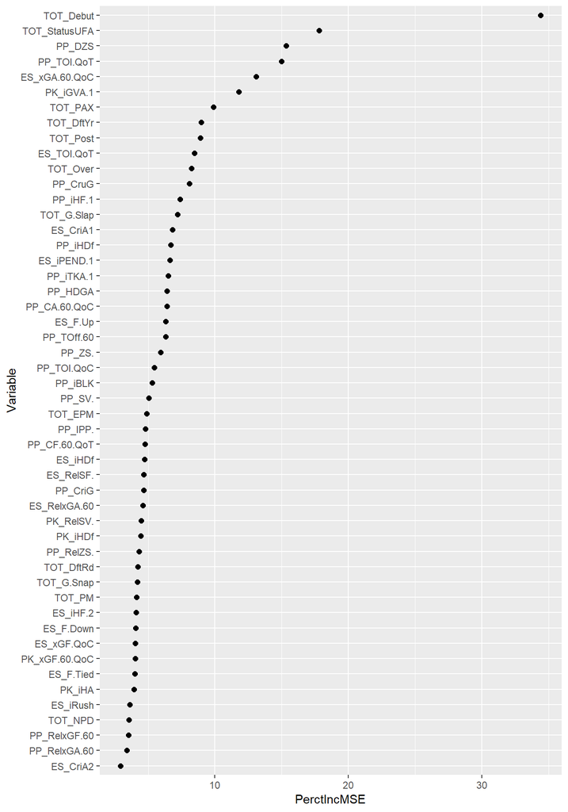

```r
results[["random_forest"]][["importance"]]
```

For “variable importance” for linear regression, you can look directly at the coefficients, standard errors, and p-values from the fitte model

```r
summary(results[["linear_regression"]][["predictor"]]$finalModel)
```

```
##
## Call:
## NULL
##
## Deviance Residuals:
##      Min        1Q    Median        3Q       Max
## -3891566   -870206     10747    767975   6440341
##
## Coefficients: (4 not defined because of singularities)
##                  Estimate  Std. Error t value      Pr(>|t|)
## (Intercept)   195699628.2  46433958.9   4.215 0.00002920836 ***
## TOT_Debut           229.2       729.4   0.314      0.753444
## TOT_StatusUFA   1017739.8    175017.2   5.815 0.00000001024 ***
## PP_TOI.QoT        20186.5      9657.2   2.090      0.037045 *
## PP_DZS           -19185.3     26388.7  -0.727      0.467516
## TOT_DftYr       -102151.2     22406.3  -4.559 0.00000632676 ***
## ES_xGA.60.QoC   2057181.2   1422977.8   1.446      0.148829
## PK_iGVA.1        114214.2     33101.8   3.450      0.000602 ***
## PP_CruG           93602.1     72361.5   1.294      0.196365
## PP_TOI.QoC        -8684.1     16243.4  -0.535      0.593126
## ES_TOI.QoT       260007.8     70267.4   3.700      0.000237 ***
## TOT_Over           8465.4     26828.8   0.316      0.752475
## PP_iTKA.1        -26621.7     60436.0  -0.440      0.659751
## TOT_PAX          -45812.2      7646.9  -5.991 0.00000000375 ***
## PP_iHF.1         134471.2     45330.6   2.966      0.003142 **
## ES_RopFOW        104948.7     29966.0   3.502      0.000498 ***
## PP_CA.60.QoC       5718.1     11000.2   0.520      0.603399
## PK_iTKA.1         19385.8     29754.6   0.652      0.514979
## PP_ZS.             2376.2      2752.0   0.863      0.388259
## TOT_WAR           71502.2    126318.2   0.566      0.571590
## PP_iHDf          -79746.7     29887.7  -2.668      0.007848 **
## ES_F.Tied           861.4      2213.9   0.389      0.697358
## PP_HDGA          123044.4     68540.9   1.795      0.073166 .
## PK_iHDf            6203.5     23439.0   0.265      0.791365
## ES_F.Up            1148.4      2655.9   0.432      0.665634
## ES_CriA1         155897.5     59366.9   2.626      0.008878 **
## PK_iHA            69009.7     58909.3   1.171      0.241918
## PP_TOff.60         -712.1      3465.9  -0.205      0.837289
## TOT_DftRd       -101766.0     35464.4  -2.870      0.004267 **
## ES_iPEND.1         7620.9     16834.3   0.453      0.650943
```

[output cut: 52 more lines]

```
## PositionRW       214390.9    201088.8   1.066      0.286819
## PK_xGF.60.QoC     59503.2    109652.9   0.543      0.587588
## ES_iHF.2          -5359.3      2877.0  -1.863      0.063021 .
## TOT_OTG          246848.8    136481.7   1.809      0.071045 .
## ES_RelxGA.60      -7925.3    121999.7  -0.065      0.948228
## ---
## Signif. codes:  0 '***' 0.001 '**' 0.01 '*' 0.05 '.' 0.1 ' ' 1
##
## (Dispersion parameter for gaussian family taken to be 2016326992581)
##
##     Null deviance: 3866421339308743  on 637  degrees of freedom
## Residual deviance: 1119061480882297  on 555  degrees of freedom
## AIC: 19966
##
## Number of Fisher Scoring iterations: 2
```

Note that these are the results of a single run, and numbers are close enough that the samples used during each run could have an impact on this result. For robustness, we can run the analysis many times (without controlling the seed), and explore the central tendancy and variation.

The mean results after 20 iterations are in the folowing table. I did not set the seed to explore variation in results, but for publishing or sharing results, we would control the seed.

| Model | Metric | Value |
| --- | --- | --- |
| k-Nearest Neighbors | MAPE | 0.7182 |
| k-Nearest Neighbors | RMSE | 1,145,584 |
| k-Nearest Neighbors | PPE10 | 0.1276 |
| Linear Regression | MAPE | 0.7932 |
| Linear Regression | RMSE | 1,022,017 |
| Linear Regression | PPE10 | 0.1134 |
| Random Forest | MAPE | 0.4237 |
| Random Forest | RMSE | 759,186 |
| Random Forest | PPE10 | 0.2234 |

Also note that these results show that the predictive powerful for these models is terrible (which I will discuss in the discussion below) The Random Forest model only predicted 22% of the players salaries within 10% of there actual salary.

## Sample Predictions

My favourite player is Connor McDavid of MY Edmonton Oilers so chose to look at his case and 9 other random players from the data

Data we will use for predictions:

```r
select <- which(
    colnames(data[["full"]]) %in%
    c(colnames(selection[["data"]][["full"]]), ID_VARS)
)
d <- data[["full"]][, select]
```

Connor McDavid observation:

```r
connor_mcdavid <- d[
    d$Last.Name == "McDavid" &
    d$First.Name == "Connor" &
    d$Position == "C" &
    d$Team == "EDM",
]
```

```r
players <- d[sample(1:nrow(d), 9), ]
players <- rbind(connor_mcdavid, players)
```

Get the actual predictions:

```r
avoid <- -which(colnames(players) %in% c(
    "Year",
    "Last.Name",
    "First.Name"
))
predictions <- predict(
    results[["random_forest"]][["predictor"]],
    players[, avoid]
)
```

Results for predictions, including Root-Square Error (RSE), Absolute Error (AE), and Absolute Percentage Error (APE).

```r
res <- data.frame(
    "First.Name" = players$First.Name,
    "Last.Name" = players$Last.Name,
    "Position" = players$Position,
    "Team" = players$Team,
    "Real" = players$Salary,
    "Predicted" = predictions
)
res$RSE <- sqrt((res$Real - res$Predicted)^2)
res$AE <- abs(res$Real - res$Predicted)
res$APE <- res$AE / res$Real

res
```

|  | First.Name | Last.Name | Position | Team | Real | Predicted | RSE | AE | APE |
| --- | --- | --- | --- | --- | --- | --- | --- | --- | --- |
| 561 | Connor | McDavid | C | EDM | 925000 | 5174906.3 | 4249906.350 | 4249906.350 | 4.594493351 |
| 274 | Derek | Forbort | D | LAK | 650000 | 1229289.7 | 579289.660 | 579289.660 | 0.891214861 |
| 778 | Andrej | Sekera | D | EDM | 5500000 | 2654593.4 | 2845406.647 | 2845406.647 | 0.517346663 |
| 62 | Chris | Bigras | D | COL | 832500 | 837008.8 | 4508.831 | 4508.831 | 0.005416013 |
| 618 | Matt | Nieto | LW | COL | 1000000 | 1152297.4 | 152297.440 | 152297.440 | 0.152297440 |
| 547 | Alec | Martinez | D | LAK | 4000000 | 4243036.0 | 243036.042 | 243036.042 | 0.060759010 |
| 492 | Johan | Larsson | C | BUF | 1400000 | 2631012.2 | 1231012.183 | 1231012.183 | 0.879294416 |
| 682 | Neal | Pionk | D | NYR | 925000 | 999097.8 | 74097.800 | 74097.800 | 0.080105730 |
| 138 | Michael | Chaput | C | VAN | 687500 | 770786.3 | 83286.312 | 83286.312 | 0.121143726 |
| 722 | Morgan | Rielly | D | TOR | 5000000 | 3989809.2 | 1010190.763 | 1010190.763 | 0.202038153 |

## Discussion

I was curious to see if one year of data could produce a good prediction model for salary. This was not the case. There is a great deal of model polishing and tuning that could still be done, however, this dataset is limited. The data for the model only included one year (when a second year was added there was not improvement). The data does not take into accound change in salary contracts over time and status. For example Connor McDavid won the scoring title but was in his first contract, which is capped at $950,000 by NHL mandate. In the following Year his salary increased to 12.5 Million. THis example illustrates the obvious short comings of my dataset. I had a difficult time finding the appropriate contract data to match but this is a necessary next step.